# India Urban Climate Analysis 2020–2025

## 6.2 6.2 Correlation Matrix

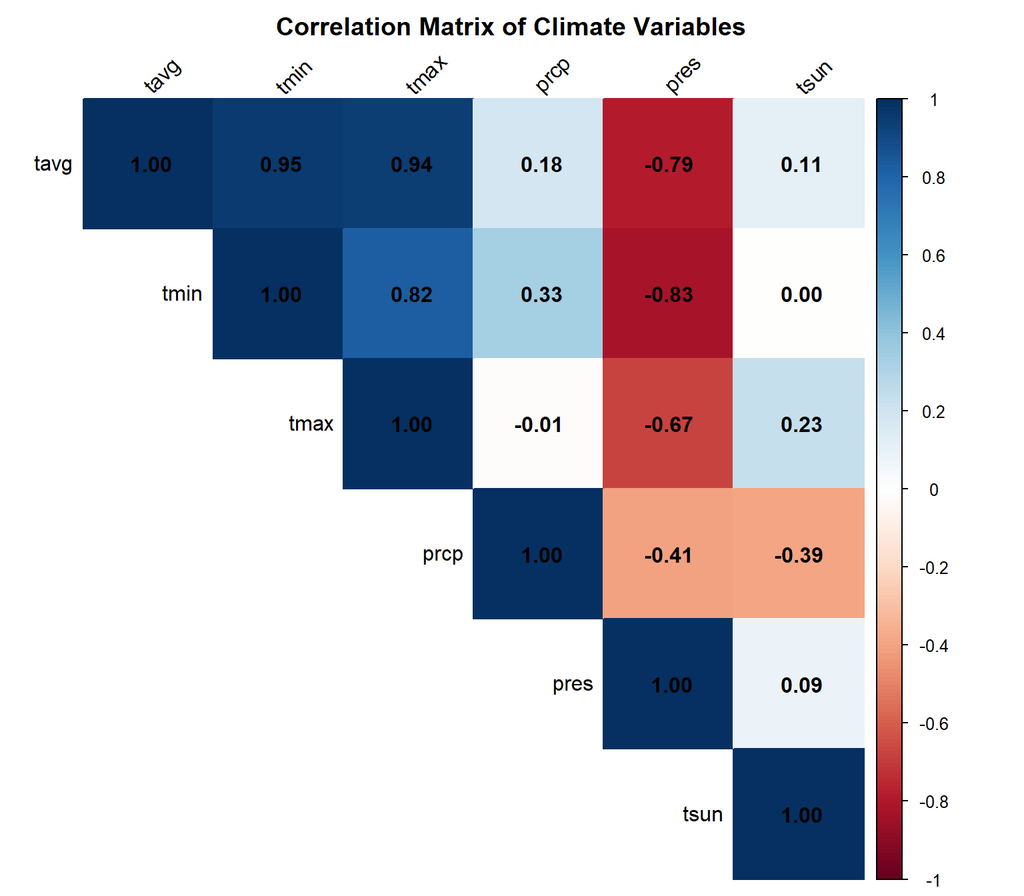

```r
cor_data <- df %>%
  select(tavg, tmin, tmax, prcp, pres, tsun) %>%
  drop_na()

cor_matrix <- cor(cor_data)

corrplot(cor_matrix,
         method      = "color",
         type        = "upper",
         addCoef.col = "black",
         tl.col      = "black",
         tl.srt      = 45,
         title       = "Correlation Matrix of Climate Variables",
         mar         = c(0, 0, 2, 0))
```

# 7 City Comparison

## 7.1 Temperature Trends — Major Cities

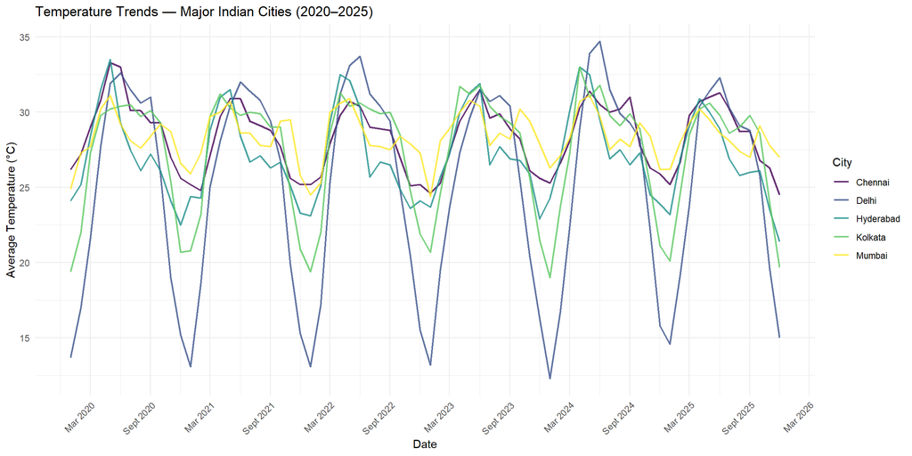

```r
major_cities <- c("Mumbai", "Delhi", "Chennai",
                  "Kolkata", "Bangalore", "Hyderabad")

df %>%
  filter(city %in% major_cities) %>%
  group_by(city, date) %>%
  summarise(avg_temp = mean(tavg, na.rm = TRUE), .groups = "drop") %>%
  ggplot(aes(x = date, y = avg_temp, color = city)) +
  geom_line(linewidth = 0.8, alpha = 0.8) +
  scale_color_viridis_d() +
  labs(title = "Temperature Trends — Major Indian Cities (2020–2025)",
       x = "Date", y = "Average Temperature (°C)", color = "City") +
  theme_minimal() +
  scale_x_date(date_breaks = "6 months", date_labels = "%b %Y") +
  theme(axis.text.x = element_text(angle = 45, hjust = 1))
```

# 8 Stationarity Test — Mumbai

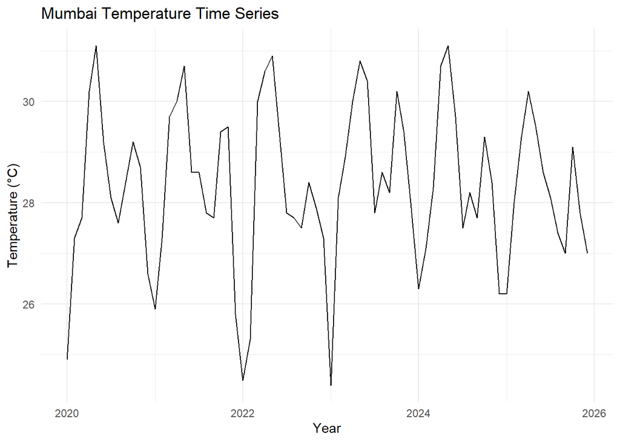

```r
# Extract Mumbai temperature time series
mumbai_ts <- df %>%
  filter(city == "Mumbai") %>%
  arrange(date) %>%
  pull(tavg)

mumbai_ts <- ts(mumbai_ts, start = c(2020, 1), frequency = 12)

# Plot the time series first
autoplot(mumbai_ts) +
  labs(title = "Mumbai Temperature Time Series",
       x = "Year", y = "Temperature (°C)") +
  theme_minimal()
```

Clear seasonal cycles every year No upward/downward drift — confirms stationarity

## 8.1 ADF Test (Augmented Dickey-Fuller)

```r
# ADF Test — tests for stationarity
# H0: Series is NON-stationary
# H1: Series IS stationary
adf_result <- adf.test(mumbai_ts)
print(adf_result)
```

```
##
##  Augmented Dickey-Fuller Test
##
## data:  mumbai_ts
## Dickey-Fuller = -3.7855, Lag order = 4, p-value = 0.02433
## alternative hypothesis: stationary
```

```r
cat("\n")
```

```r
if (adf_result$p.value < 0.05) {
  cat("✅ p-value =", round(adf_result$p.value, 4), "\n")
  cat("✅ Series is STATIONARY — no differencing needed\n")
} else {
  cat("❌ p-value =", round(adf_result$p.value, 4), "\n")
  cat("❌ Series is NON-STATIONARY — differencing needed\n")
}
```

```
## ✅ p-value = 0.0243
## ✅ Series is STATIONARY — no differencing needed
```

p-value = 0.0243 (less than 0.05) Series is STATIONARY — no differencing needed

## 8.2 ACF & PACF Plots

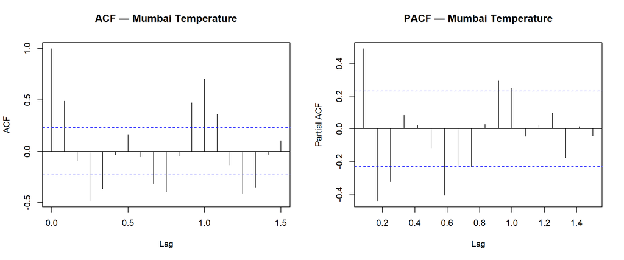

```r
# ACF and PACF help determine ARIMA parameters
par(mfrow = c(1, 2))
acf(mumbai_ts,  main = "ACF — Mumbai Temperature")
pacf(mumbai_ts, main = "PACF — Mumbai Temperature")
```

ACF shows significant spikes at lag 1.0 — strong seasonality PACF cuts off quickly — suggests AR terms needed

## 8.3 ARIMA Model — Mumbai

```r
# auto.arima automatically selects best ARIMA parameters
fit_mumbai <- auto.arima(mumbai_ts,
                          seasonal = TRUE,
                          stepwise = FALSE,
                          approximation = FALSE)

cat("Best ARIMA Model for Mumbai:\n")
```

```
## Best ARIMA Model for Mumbai:
```

```r
summary(fit_mumbai)
```

```
## Series: mumbai_ts
## ARIMA(0,0,0)(2,1,0)[12]
##
## Coefficients:
##          sar1     sar2
##       -0.6805  -0.4717
## s.e.   0.1267   0.1293
##
## sigma^2 = 0.6089:  log likelihood = -73.69
## AIC=153.38   AICc=153.81   BIC=159.67
##
## Training set error measures:
##                      ME      RMSE       MAE        MPE     MAPE      MASE
## Training set 0.03772381 0.7003611 0.5155291 0.09907398 1.838487 0.6444113
##                   ACF1
## Training set 0.1204975
```

## 8.4 Forecast — Next 12 Months

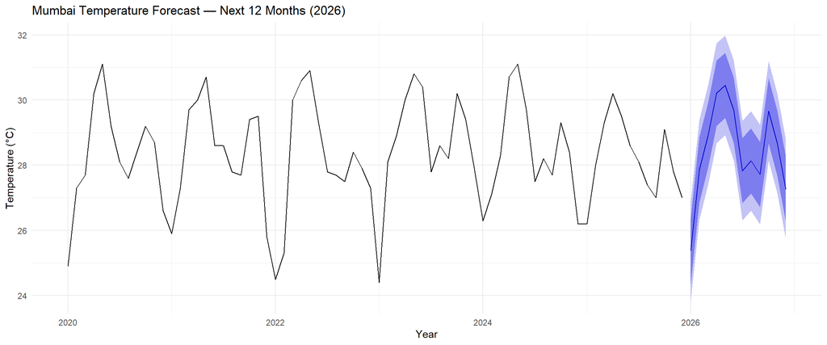

```r
forecast_mumbai <- forecast(fit_mumbai, h = 12)

autoplot(forecast_mumbai) +
  labs(title = "Mumbai Temperature Forecast — Next 12 Months (2026)",
       x = "Year", y = "Temperature (°C)") +
  theme_minimal() +
  theme(plot.title = element_text(fontface = "bold"))
```

## 8.5 Model Accuracy

```r
acc <- accuracy(fit_mumbai)
cat("Model Accuracy Metrics:\n")
```

```
## Model Accuracy Metrics:
```

```r
print(acc)
```

```
##                      ME      RMSE       MAE        MPE     MAPE      MASE
## Training set 0.03772381 0.7003611 0.5155291 0.09907398 1.838487 0.6444113
##                   ACF1
## Training set 0.1204975
```

```r
cat("\nForecast Values for Next 12 Months:\n")
```

```
##
## Forecast Values for Next 12 Months:
```

```r
print(round(forecast_mumbai$mean, 2))
```

```
##        Jan   Feb   Mar   Apr   May   Jun   Jul   Aug   Sep   Oct   Nov   Dec
## 2026 25.37 27.86 28.90 30.21 30.45 29.68 27.83 28.13 27.71 29.66 28.68 27.26
```

The **ARIMA(0,0,0)(2,1,0)[12]** model captures Mumbai’s seasonal temperature pattern with high accuracy — **MAPE of only 1.84%** meaning predictions are within 2% of actual values. The 2026 forecast shows peak temperatures of **30.5°C in May** dropping to **25.4°C in January**, consistent with Mumbai’s historical seasonal pattern.

# 9 Stationarity Test — Delhi

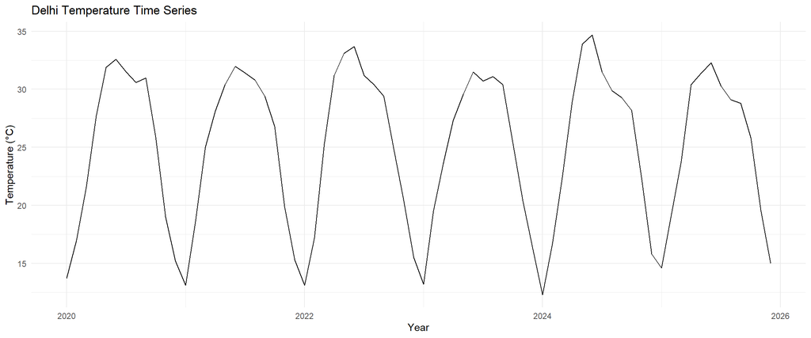

```r
delhi_ts <- df %>%
  filter(city == "Delhi") %>%
  arrange(date) %>%
  pull(tavg)

delhi_ts <- ts(delhi_ts, start = c(2020, 1), frequency = 12)

# Plot Delhi time series
autoplot(delhi_ts) +
  labs(title = "Delhi Temperature Time Series",
       x = "Year", y = "Temperature (°C)") +
  theme_minimal()
```

## 9.1 Delhi ADF Test

```r
adf_delhi <- adf.test(delhi_ts)
print(adf_delhi)
```

```
##
##  Augmented Dickey-Fuller Test
##
## data:  delhi_ts
## Dickey-Fuller = -6.4115, Lag order = 4, p-value = 0.01
## alternative hypothesis: stationary
```

```r
cat("\n")
```

```r
if (adf_delhi$p.value < 0.05) {
  cat("✅ p-value =", round(adf_delhi$p.value, 4), "\n")
  cat("✅ Delhi series is STATIONARY — no differencing needed\n")
} else {
  cat("❌ p-value =", round(adf_delhi$p.value, 4), "\n")
  cat("❌ Delhi series is NON-STATIONARY — differencing needed\n")
}
```

```
## ✅ p-value = 0.01
## ✅ Delhi series is STATIONARY — no differencing needed
```

## 9.2 8.8 Delhi ACF & PACF

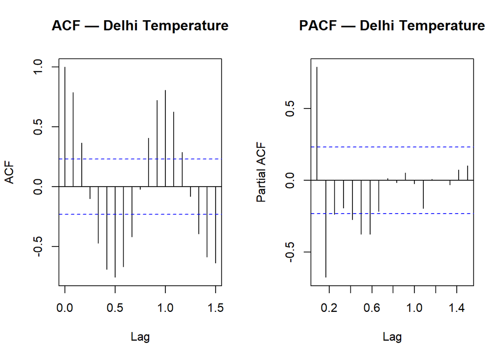

```r
par(mfrow = c(1, 2))
acf(delhi_ts,  main = "ACF — Delhi Temperature")
pacf(delhi_ts, main = "PACF — Delhi Temperature")
```

## 9.3 ARIMA Model — Delhi

```r
fit_delhi <- auto.arima(delhi_ts,
                         seasonal = TRUE,
                         stepwise = FALSE,
                         approximation = FALSE)

cat("Best ARIMA Model for Delhi:\n")
```

```
## Best ARIMA Model for Delhi:
```

```r
summary(fit_delhi)
```

```
## Series: delhi_ts
## ARIMA(0,0,1)(0,1,2)[12]
##
## Coefficients:
##          ma1     sma1    sma2
##       0.6761  -0.9693  0.3538
## s.e.  0.1097   0.1849  0.2191
##
## sigma^2 = 0.977:  log likelihood = -89.11
## AIC=186.21   AICc=186.94   BIC=194.59
##
## Training set error measures:
##                      ME      RMSE       MAE       MPE    MAPE      MASE
## Training set 0.07908028 0.8794658 0.6484723 0.2709128 2.68525 0.4588247
##                     ACF1
## Training set -0.03974058
```

## 9.4 Delhi Forecast — Next 12 Months

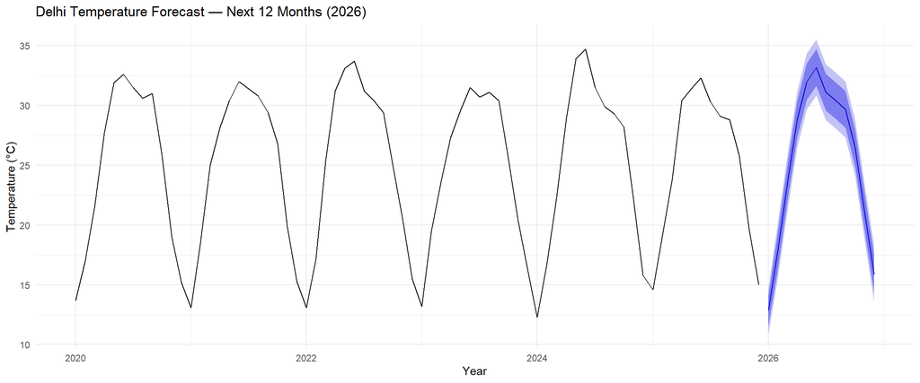

```r
forecast_delhi <- forecast(fit_delhi, h = 12)

autoplot(forecast_delhi) +
  labs(title = "Delhi Temperature Forecast — Next 12 Months (2026)",
       x = "Year", y = "Temperature (°C)") +
  theme_minimal() +
  theme(plot.title = element_text(fontface = "bold"))
```

The **Delhi ARIMA(0,0,1)(0,1,2)[12]** model forecasts a peak temperature of **33°C in June 2026** dropping sharply to **16°C in December 2026**. The narrow confidence interval (blue shading) indicates high forecast confidence. Delhi’s extreme seasonal swing of nearly **20°C** between winter and summer is clearly captured by the model.